# Forest Type Prediction in Kaggler

Luis Argerich

Saturday, August 02, 2014

# Forest Type Prediction in Kaggler

# Task Description

This competition is about predicting the forest cover type based on several geographical features such as Elevation, Distance to hydrology, slope, etc. There are a total of 7 (seven) different forest cover types so it’s a multiclass classification problem.

# Approach & Techniques

I used R for this project. The dataset is particularly tidy so it didn’t need much pre-processing. I removed variables that had no variation at all in the training set. These are the pre-processing steps.

```r
library(randomForest)
```

```r
library(C50)
library(ggplot2)

# Read datasets
train<-read.csv("train.csv")
test<-read.csv("test.csv")

# Pull cover_type and id
cover_type<-as.factor(train$Cover_Type)
id<-test$Id

# Remove cover_type from training set (this is what we want to predict)
train$Cover_Type<-NULL

# Join both datasets
combi <- rbind(train, test)

# Remove Unused variables
combi$Soil_Type7<-NULL
combi$Soil_Type15<-NULL

# Remove Ids
combi$Id<-NULL

# Recreate training and test datasets
train <- combi[1:15120,]
test <- combi[15121:581012,]
```

# Implementation

After exploring different algorithms I settled on a randomForest for this project, randomForests are easy to use and tune. I used tuneRF to find the best parameters and then used this:

```r
clf <- randomForest(train, as.factor(cover_type), ntree=500, mtry=8, importance=TRUE)
```

The returned object can be used to see how the algorithm fared displaying a confusion matrix.

```r
clf
```

```
##
## Call:
##  randomForest(x = train, y = as.factor(cover_type), ntree = 500,      mtry = 8, importance = TRUE)
##                Type of random forest: classification
##                      Number of trees: 500
## No. of variables tried at each split: 8
##
##         OOB estimate of  error rate: 15.26%
## Confusion matrix:
##      1    2    3    4    5    6    7 class.error
## 1 1613  327    2    0   57   10  151     0.25324
## 2  364 1492   49    0  167   70   18     0.30926
## 3    0    7 1613  141   27  372    0     0.25324
## 4    0    0   34 2096    0   30    0     0.02963
## 5    2   58   37    0 2032   31    0     0.05926
## 6    0    9  177   74   15 1885    0     0.12731
## 7   75    1    1    0    1    0 2082     0.03611
```

Random Forests can also be used to explore the importance of features for prediction

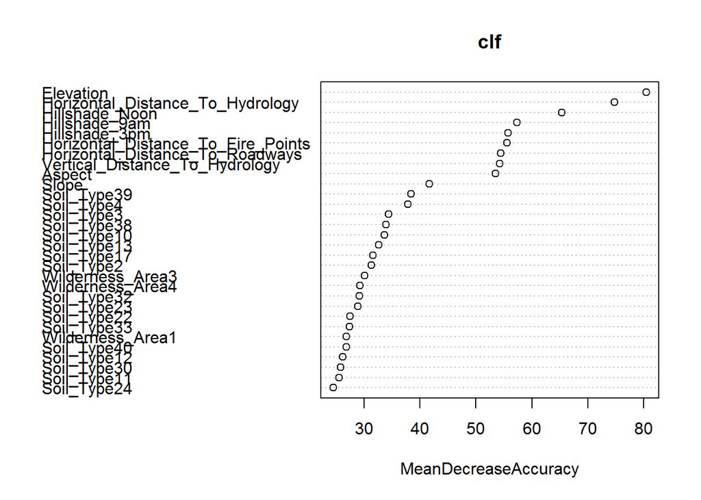

```r
varImpPlot(clf,type=1)
```

It seems the Elevation feature is the most important one, and that makes sense because forest depends a lot on the terrain altitude. One problem with this is that an algorithm might use only the elevation to predict but a RandomForest will pick features randomly so it’s forced to use different sets of attributes in different trees.

I created a prediction from the model and a submission with this code:

```r
result=predict(clf, test)
submit <- data.frame(Id = id, Cover_Type = result)
write.csv(submit, file = "basic_random_forest.csv", row.names = FALSE)
```

This got to around 0.75 score which is about the middle of the leaderboard.

# Did it Work?

Yes this worked but in the confusion matrix it can be seen that the algorithm struggles with cover types 1 and 2. Sometimes a cover type 1 is classified as 2 and sometimes a 2 is classified as 1.

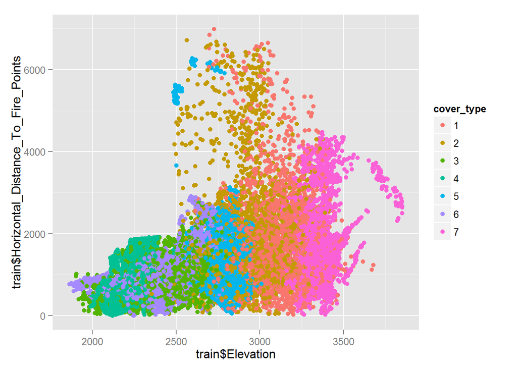

```r
qplot(train$Elevation,train$Horizontal_Distance_To_Fire_Points,color=cover_type)
```

The plot shows clearly that the Elevation is the best predictor and that there’s a lot of mixing between forest cover type 1 and 2.

# Improvements

I tried several different algorithms and feature engineering tricks without much success. The only small improvement I found was to use an autoencoder to create 8 features from all the sparse features in the dataset (soil types and wilderness areas). I took this from a post in the Kaggle forum and you can download the code from there, I won’t include it in this report because it’s quite large.

Using the Autoencoder I went down to 18 features and the score went up to 0.77 which was good enough to be in the 61st position at the time this report was written.

# Further Work

I believe that the next effort should focus in how to untangle forest cover types 1 and 2. But I’m not sure how to do that yet.

Thanks for reading!